# Can Turkish Electricity Distribution Companies Predict the Future Well?

Alkım Can Çelik

05.07.2019

## Introduction

This report has been prepared to analyze demand forecast reports of 21 distribution companies for next 10 years. The main goal is to compare the companies in terms of forecasting.

## Key Takeaways

- In overall, only 7 of 21 companies could find an accurate interval for yearly gross electricity consumption. These are ADM, çoruh, Dicle, AYEDAŞ, Trakya, Vangölü, and Yeşilırmak Elektrik Dağıtım A.Ş. For further explanation and graph, please click.
- It can be clearly seen that companies who have success in their gross consumption forecasts have also close peak demand predictions(yearly average of summer and winter terms) to the author’s peak demand predictions in 2017. For further explanation and graph, please click.
- Generally, companies tend to increase their gross electricity consumption forecasts for the same year report by report(demand forecast reports published in 2017,2018,and 2019) in high scenario, especially from 2017 to 2018. For further explanation and graph, please click.
- It can be clearly realized that all companies have a tendency to increase their rate of increase in gross electricity consumption prediction in high scenario year by year in all reports. There is no decline in high scenario. For further explanation and graph, please click.
- Peak demand predictions made by companies tend to increase for the same year report by report in high scenario. There are also declines in reports when these are compared to each other. For further explanation and graph, please click.

## Comparison Between the Predictions about Gross Electricity Consumptions and Real Consumption in 2017

This graph has been plotted by using rate of increase in gross electricity consumption from 2016 to 2017 in order to simplify the visualization. This graph shows the companies’ prediction intervals and real consumption in their region in 2017. When we analyze the graph, it can be clearly realized that 14 of 21 companies could not predict well the gross electricity consumption in 2017. Moreover, real consumption exceeds their predictions, except Osmangazi Elektrik Dağıtım A.Ş. The reason behind the higher consumption than predictions may be extreme weather conditions in both summer and winter in 2017. Çamlibel Elektrik Dağıtım A.Ş. is the worst making forecast compared to others. Maybe continental climate in its region is the reason of that but real reason cannot be found.

In addition, it must be said that although most companies predict their base scenario taking mean of high and low scenarios, AYEDAŞ, Başkent and Toroslar Elektrik Dağıtım A.Ş. predict their base scenarios close to high scenario. Even though Başkent and Toroslar fail to predict the real consumption, it must be seen as a success because they have foreseen the high electricity consumption.

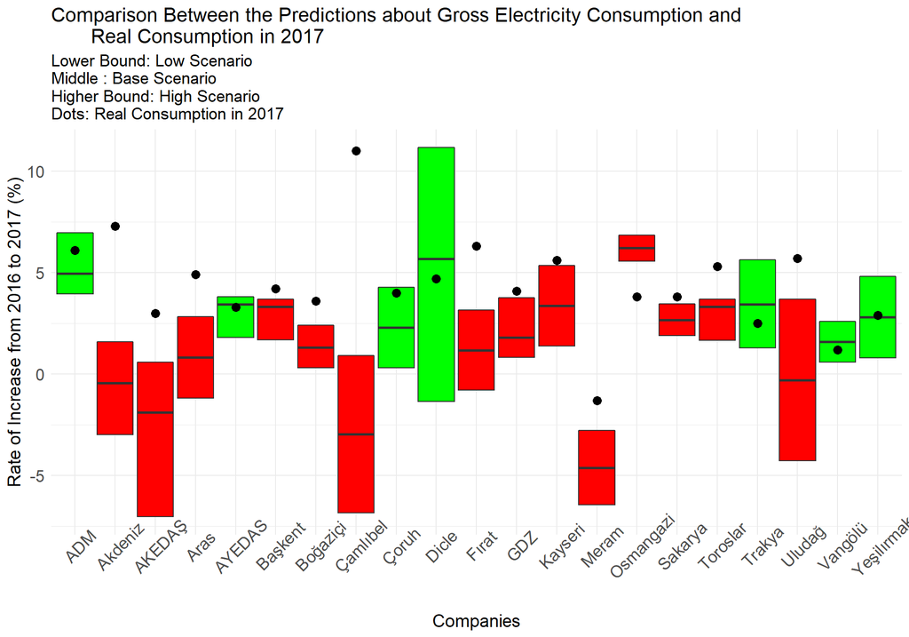

```r
ggplot(data = ratio_2017_over_2016)+ geom_boxplot(aes(x=Companies,ymin= Low_ratio,
            ymax= High_ratio,lower=Low_ratio,upper=High_ratio,middle=Base_ratio,
            fill=ifelse(Ratio <= High_ratio & Ratio >=Low_ratio, "green","red")),
stat = "identity",
position=position_dodge2(width = 0.9,  preserve = "single"))+
  geom_point(size = 3,aes(x=Companies,y=Ratio) ,stat="identity") +
  theme_minimal()+
  theme(axis.text.x = element_text(size = 13, angle = 45),
axis.title.x = element_text(size = 14),axis.title.y = element_text(size = 14),
axis.text.y = element_text(size = 13), title = element_text(size = 13),
legend.position = "none") + scale_fill_manual(values = c("green","red"))+
  labs(title = "Comparison Between the Predictions about Gross Electricity Consumption and
       Real Consumption in 2017",
subtitle = "Lower Bound: Low Scenario
Middle : Base Scenario
Higher Bound: High Scenario
Dots: Real Consumption in 2017",
y="Rate of Increase from 2016 to 2017 (%)")
```

## Comparison between the Predictions Made by Companies and Predictions Made by Author about Peak Demand in 2017

This graph has been prepared to compare companies’ peak demand predictions and author’s peak demand predictions for 2017. Since there is no information about real peak demand in 2017 for each company, peak demand for each company have been predicted by using real gross electricity consumption values in 2017.

Fistly, the closest scenario prediction of gross electricity consumption to real consumption for each company is found. Then, the peak demand prediction made for that scenario is divided to gross consumption prediction for that scenario for each company. After that, the ratio and the real consumption in 2017 for each company are multiplied. Finally, the proportional divergence is obtained.

Like the graph above, author’s predictions are closer to companies’ predictions where companies’ predictions of gross electricity consumptions and real consumptions are close. 15 of 21 companies have made better prediction in high scenario compared to other scenarios. Like success in gross electricity consumption forecast, Yeşilırmak Elektrik Dağıtım A.Ş. has the least deviation in its peak demand prediction from the peak demand prediction made by author.

Most companies’ peak demand predictions are lower than author’s prediction, like predictions of gross electricity consumption. Çamlibel Elektrik Dağıtım A.Ş. is the worst company for making peak demand prediction. Osmangazi Elektrik Dağıtım A.Ş. has the highest divergence rate. This calculation shows that when companies make peak demand predictions, they take gross electricity consumptions into consideration as expected. It means this formula can be used to get close peak demand value to real peak demand.

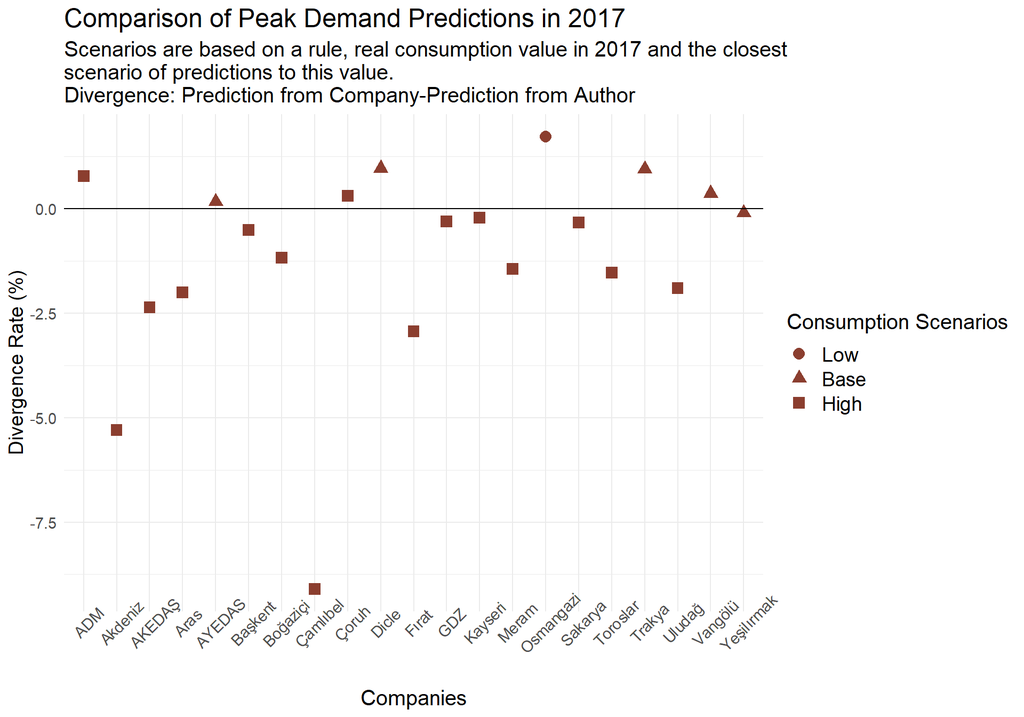

```r
ggplot(data = predicted_peak_demand_2017, aes(x=Companies,y=ratio ,shape=min)) +
  geom_point(size=3.5, colour = "coral4")+
scale_colour_discrete(name  ="Predictions",breaks=c("peak_demand_predicted_by_hand",
                                                    "predict_from_company"),
labels=c("By Author", "By Company"))+scale_shape_discrete(name = "Level",
                breaks=c("Low Scenario", "Base Scenario", "High Scenario"))+
  theme_minimal()+theme(axis.text.x = element_text(size=11, angle = 45),
  axis.text.y = element_text(size = 11), legend.text = element_text(size = 14),
  axis.title.y = element_text(size = 14) ,legend.title = element_text(size = 15),
  title = element_text(size=15)) +
  labs(title = "Comparison of Peak Demand Predictions in 2017",
subtitle = "Scenarios are based on a rule, real consumption value in 2017 and the closest
scenario of predictions to this value.
Divergence: Prediction from Company-Prediction from Author",y="Divergence Rate (%)") +
  scale_shape_manual(values = c(16,17,18))+
  scale_shape_discrete(name="Consumption Scenarios",limits = c("Low", "Base", "High")) +
  geom_hline(yintercept = 0)
```

## Variability in Gross Electricity Consumption Forecasts between Reports in High Scenario

This graph has been plotted in order to compare predictions of gross electricity consumption for each year report by report. It consists of rates of increase in predictions of gross electricity consumption for the same year report by report. For instance, AKEDAŞ increases its predictions 5% in average for the same years from report written in 2017 to report written in 2018.

Most companies increase their predictions from 2017 to 2018 because the unexpected consumption in 2017 probably makes companies realize how their predictions are low. Based on the comparison between predictions of gross electricity consumption and real consumption in 2017, it can be seen that companies who had high predictions compared to real consumption decreases their predictions in 2018 against 2017 and vice versa. MEDAŞ increases its predictions extraordinarily from report in 2017 to report in 2018. Maybe it results from investments in agricultural irrigation.

From report in 2018 to report in 2019, companies tend to diminish their predictions of gross electricity consumption. Since businesses and factories constitute approximately 71 percent of total electricity consumption, economic crisis in 2018 should be a good reason for this decline.

Last graph is a summary for the other report comparisons. Generally, companies tend to increase their predictions. The most enhancer company is MEDAŞ, the least enhancer company is Trakya Elektrik Dağıtım A.Ş. Trakya and Boğaziçi Elektrik Dağıtım A.Ş. have the widest intervals, which means they are not consistent when they change their predictions for the same year report by report. For instance, TREDAŞ diminishes its prediction 32 percent for 2026 from report in 2017 to report in 2019. However, for 2019, it diminishes its prediction 11 percent from report in 2017 to report in 2019. ADM Elektrik Dağıtım A.Ş. is the most consistent in its predictions when its reports are compared.

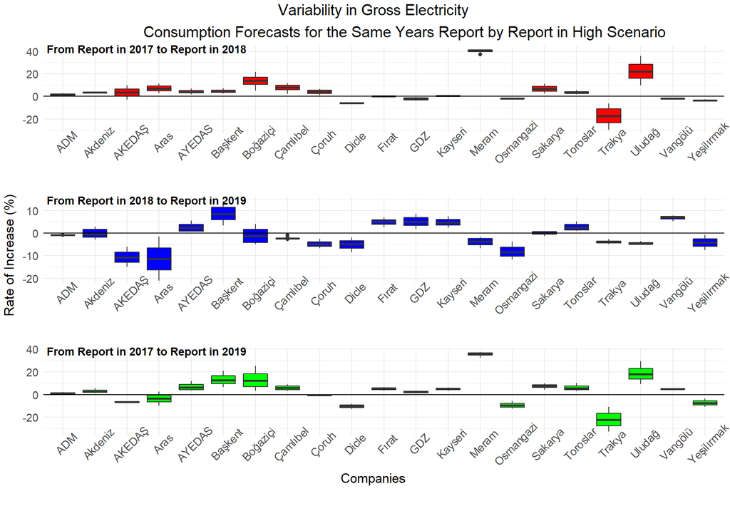

```r
from_2017_to_2018_gross <- ggplot(data = gross_comparison_reports %>%
  filter(variable=="rise_2018_over_2017"), aes(x=Companies,y=value))+
  geom_boxplot(fill="red") + theme_minimal() +
  theme(axis.text.x = element_text(angle = 45, size = 11),
axis.text.y = element_text(size = 11), legend.text = element_text(size = 11))+
  labs(y = NULL, x= NULL) +
  geom_hline(yintercept = 0)

from_2018_to_2019_gross <- ggplot(data = gross_comparison_reports %>%
  filter(variable=="rise_2019_over_2018"), aes(x=Companies,y=value))+
  geom_boxplot(fill="blue") + theme_minimal() +
  theme(axis.text.x = element_text(angle = 45, size = 11),
  axis.text.y = element_text(size = 11),legend.text = element_text(size = 11))+
  labs(y = NULL, x= NULL) +
  geom_hline(yintercept = 0)

from_2017_to_2019_gross <- ggplot(data = gross_comparison_reports %>%
  filter(variable=="rise_2019_over_2017"), aes(x=Companies,y=value))+
  geom_boxplot(fill="green") + theme_minimal() +
  theme(axis.text.x = element_text(angle = 45, size = 11),
  axis.text.y = element_text(size = 11),legend.text = element_text(size = 11))+
  labs(y = NULL, x= NULL) +
  geom_hline(yintercept = 0)

variability_gross_figure <- ggarrange(from_2017_to_2018_gross,
  from_2018_to_2019_gross, from_2017_to_2019_gross, nrow=3, ncol=1,
  labels = c("From Report in 2017 to Report in 2018",
             "From Report in 2018 to Report in 2019",
             "From Report in 2017 to Report in 2019"),
  font.label = list(size = 11), hjust = -.15)

annotate_figure(variability_gross_figure, top = text_grob("Variability in Gross Electricity
               Consumption Forecasts for the Same Years Report by Report in High Scenario",
               size = 15),
               bottom = text_grob("Companies", size = 13, vjust = -2),
               left = text_grob("Rate of Increase (%)", size = 13, rot = 90))
```

## Variability in Peak Demand Forecasts between Reports in High Scenario

This graph has been prepared to compare peak demand predictions for each year report by report in high scenario. Compared to above graph, this graph shows us there is a weak correlation between this graph and the above graph.

Like the above graph, most companies tend to inrease their peak demand predictions from report in 2017 to report in 2018. Although there are incompetible results, companies who have peak demand predictions that exceed the prediction by author tend to decrease their forecasts and vice versa.

From report in 2018 to report in 2019, like predictions of gross electricity consumption, there are declines in predictions in most companies.

To sum up, like gross electricity consumption forecasts, Boğaziçi Elektrik Dağıtım A.Ş. has the widest interval, which means Boğaziçi is less stable when they predict peak demand values for the same year report by report.

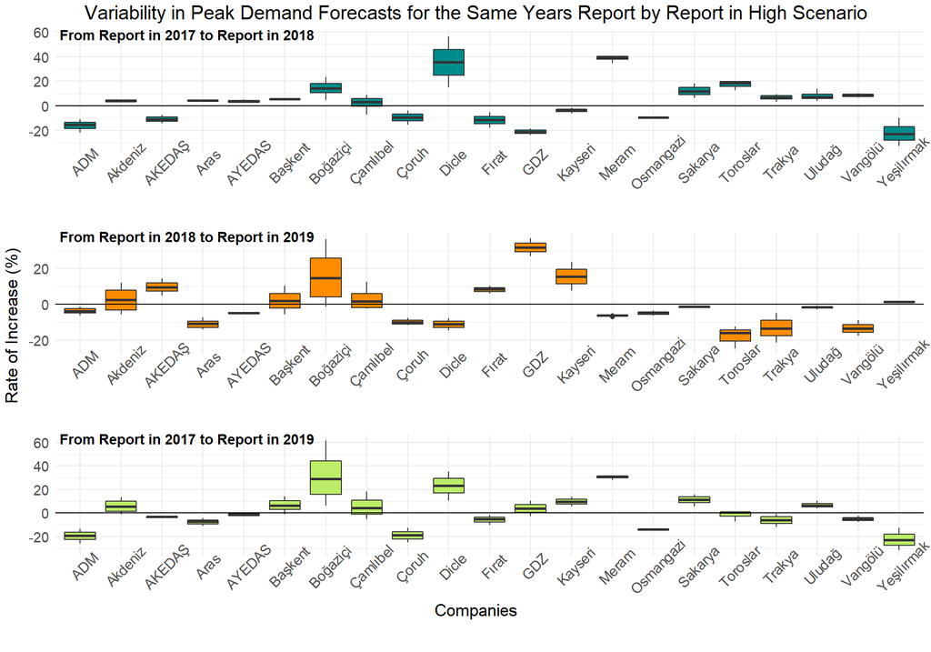

```r
from_2017_to_2018_peak_demand <- ggplot(data = peak_demand_comparison_reports %>%
                                          filter(variable=="rise_2018_over_2017"),
                                        aes(x=Companies,y=value))+
  geom_boxplot(fill="darkcyan") + theme_minimal() +
  theme(axis.text.x = element_text(angle = 45, size = 11),
        axis.text.y = element_text(size = 11), legend.text = element_text(size = 11))+
  labs(y = NULL, x= NULL)+
  geom_hline(yintercept = 0)

from_2018_to_2019_peak_demand <- ggplot(data = peak_demand_comparison_reports %>%
                                          filter(variable=="rise_2019_over_2018"),
                                        aes(x=Companies,y=value))+
  geom_boxplot(fill="darkorange") + theme_minimal() +
  theme(axis.text.x = element_text(angle = 45, size = 11),
        axis.text.y = element_text(size = 11), legend.text = element_text(size = 11))+
  labs(y = NULL, x= NULL) +
  geom_hline(yintercept = 0)

from_2017_to_2019_peak_demand <- ggplot(data = peak_demand_comparison_reports %>%
                                          filter(variable=="rise_2019_over_2017"),
                                        aes(x=Companies,y=value))+
  geom_boxplot(fill="darkolivegreen2") + theme_minimal() +
  theme(axis.text.x = element_text(angle = 45, size = 11),
        axis.text.y = element_text(size = 11),  legend.text = element_text(size = 11))+
  labs(y = NULL, x= NULL) +
  geom_hline(yintercept = 0)

variability_peak_demand_figure <- ggarrange(from_2017_to_2018_peak_demand,
                                            from_2018_to_2019_peak_demand,
                                            from_2017_to_2019_peak_demand, nrow = 3,
                                            ncol=1,
                                      labels = c("From Report in 2017 to Report in 2018",
                                                 "From Report in 2018 to Report in 2019",
                                                 "From Report in 2017 to Report in 2019"),
                                      font.label = list(size = 11), hjust = -.15)

annotate_figure(variability_peak_demand_figure,
                top = text_grob(
"Variability in Peak Demand Forecasts for the Same Years Report by Report in High Scenario",
size = 15), bottom = text_grob("Companies", size = 13, vjust = -2),
left = text_grob("Rate of Increase (%)", size = 13, rot = 90))
```

## Rate of Increase in Predictions about Gross Electricity Consumption in High Scenario Year by Year

This graph has been plotted to find which companies have the highest and lowest rates of increase year by year. There is no decline in gross electricity consumption in high scenario in three reports when compared year by year. It means all companies increase their predictions of gross electricity consumption in high scenario year by year.

The highest rates of increase in predictions of gross electricity consumption belong to Trakya Elektrik Dağıtım A.Ş., in report written in 2017. Its rates of increases are significant compared to the other rates. However, they decrease their predictions of gross electricity consumption in reports written in 2018 and 2019. Therefore, its rates of increase in gross consumption may be doubtful.

ADM Elektrik Dağıtım A.Ş. takes the second place with reports written in 2018 and 2019. ADM is one of the most consistent companies predicting gross electricity consumption, so its predictions may be more reliable than TREDAŞ. These companies have the lowest loss/leakage ratios among companies. It may be a reason for that prediction.

The lowest rate of increase among companies belongs to Uludag Elektrik Dağıtım A.Ş., in report written in 2017 for 2026 prediction. It is very close to 0%. BEDAŞ and ÇEDAŞ follow the UEDAŞ with report written in 2017. Unfortunately, this situation does not fit the loss/leakage ratio explanation above.

Determination in these rates of increases partly depends on the companies’ free will. Therefore, it is hard to find a logical explanation for their behaviours.

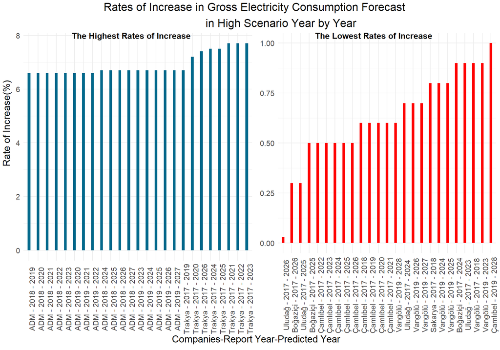

```r
positive_rise_gross <- ggplot(data = rise_gross%>%filter(level=="High") %>%
                                arrange(desc(value)) %>% slice(1:25),
                              aes(x=reorder(Companies_reportyear_years,value),y = value))+
  geom_bar(stat="identity", width = .3, fill="deepskyblue4")+labs(x=NULL,y=NULL) +
  theme_minimal()+
  theme( axis.text.x = element_text(size =11,angle = 90),
         axis.text.y.left = element_text(size = 11))

negative_rise_gross <- ggplot(data = rise_gross%>%filter(level=="High") %>%
                                arrange(value) %>% slice(1:25),
                              aes(x=reorder(Companies_reportyear_years,value),y = value))+
  geom_bar(stat="identity", width = .3, fill="red", position = "identity")+
  labs(x=NULL,y=NULL) +
  theme_minimal()+ theme(axis.text.x = element_text(size =11,angle = 90),
                         axis.text.y.left = element_text(size = 11))

rise_gross_figure <- ggarrange(positive_rise_gross,negative_rise_gross, nrow=1,ncol=2,
                               labels = c("The Highest Rates of Increase",
                                          "The Lowest Rates of Increase"),
                               font.label = list(size = 12, hjust = -1))

annotate_figure(rise_gross_figure,
top = text_grob("Rates of Increase in Gross Electricity Consumption Forecast
                in High Scenario Year by Year",
                size = 16), bottom = text_grob("Companies-Report Year-Predicted Year",
                                               size = 14, vjust = -.2),
left = text_grob("Rate of Increase(%)", size = 14, rot = 90, hjust = -.1))
```

## Rate of Increase in Predictions about Peak Demand in High Scenario Year by Year

Like the graph above, this graph has been prepared in order to find the companies who have the highest and lowest rates of increase in peak demand forecast year by year. Like the predictions of gross electricity consumption, companies tend to increase their peak demand predictions year by year.

MEDAŞ has the highest rates of increase in report published in 2018. They tend to increase their peak demand predictions in the reports year by year. Maybe it originates from increasing agricultural irrigation.

ADM Elektrik Dağıtım A.Ş. follows MEDAŞ. Like being one of the companies who have the highest rates of increase in predictions of gross electricity consumption, it has high rates of increase in peak demand prediction in the report written in 2017.

There are few negative rates of increase. The lowest,roughly -4%, belongs to Vangölü Elektrik Dağıtım A.S, for year 2025 in report in 2019. It is significantly lower than the other rates. Baskent Elektrik Dağıtım A.Ş. follows VEDAŞ with -2% rate for year 2022 in 2018.

Determination of these rates of increase in peak demand forecasts slightly depends on companies’ free will, like in rates of increase in predictions of gross electricity consumption. Although there are significant rates, it is hard to find a good reason for that behaviours.

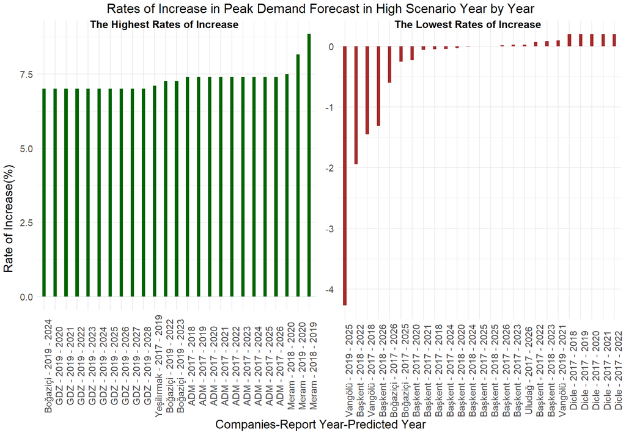

```r
positive_rise_peak_demand <- ggplot(data = rise_peak_demand%>%filter(level=="High") %>%
                                      arrange(desc(peak_demand_avg)) %>%
                                      slice(1:25),
                                    aes(x=reorder(Companies_reportyear_years,
                                                  peak_demand_avg),
                                        y = peak_demand_avg))+
  geom_bar(stat="identity", width = .3, fill="darkgreen")+labs(x=NULL,y=NULL) +
  theme_minimal()+
  theme( axis.text.x = element_text(size =11,angle = 90),
         axis.text.y.left = element_text(size = 11))

negative_rise_peak_demand <- ggplot(data = rise_peak_demand%>%
                                      filter(level=="High") %>%
                                      arrange(peak_demand_avg) %>%
                                      slice(1:25),
                                    aes(x=reorder(Companies_reportyear_years,
                                                  peak_demand_avg),
                                        y = peak_demand_avg))+
  geom_bar(stat="identity", width = .3, fill="brown", position = "identity")+
  labs(x=NULL,y=NULL) +
  theme_minimal()+ theme(axis.text.x = element_text(size =11,angle = 90),
                         axis.text.y.left = element_text(size = 11))

rise_gross_figure <- ggarrange(positive_rise_peak_demand,negative_rise_peak_demand,
                               nrow=1,ncol=2, labels = c("The Highest Rates of Increase",
                                                         "The Lowest Rates of Increase"),
                               font.label = list(size = 12, hjust = -1))

annotate_figure(rise_gross_figure,
top = text_grob("Rates of Increase in Peak Demand Forecast in High Scenario Year by Year",
                size = 15),
                bottom = text_grob("Companies-Report Year-Predicted Year", size = 14,
                                   vjust = -.2),
                left = text_grob("Rate of Increase(%)", size = 14, rot = 90))
```

## Conclusion

- After detailed observations, YEDAŞ and AYEDAŞ are the best, ÇEDAŞ and Akdeniz EDAŞ are the worst companies for making prediction about gross electricity consumption and peak demand.
- In overall, distribution companies are not actually good at making predictions.
- Unexpectedly, their gross electricity consumption and peak demand predictions are not highly correlated.
- Predictions about gross electricity consumption tend to increase year by year in high scenario.
- There are many inconsistencies in predictions report by report.

## References

https://www.teias.gov.tr/sites/default/files/2017-06/10Y%C4%B1ll%C4%B1kTalepTahminleriRaporu2016%282%29.pdf

https://www.teias.gov.tr/sites/default/files/2018-02/Taleprapor_2017.pdf

https://www.teias.gov.tr/sites/default/files/2019-06/taleprapor_2019-2028.pdf

http://epdk.gov.tr/Detay/Icerik/3-0-24/elektrikyillik-sektor-raporu

http://www.hurriyet.com.tr/ekonomi/enerjide-2017-boyle-gecti-40683149

## About the Author

Alkım Can Çelik is a data science intern who is currently working on analyzing forecasts of electricity distribution companies at Algopoly. He is studying in Industrial Engineering at Boğaziçi University. He has enthusiasm about data science and analysis, operations research, machine learning algorithms, and finance.

To contact Alkım, you can send an e-mail to alkimcancelik33@gmail.com or through [Linkedin](https://www.linkedin.com/in/alkimcelik-b8446b131/)